# Optimisation Prac-Tutorial

Published

February 16, 2025

# Question 1: Bisection Method

1. Use the bisection method to find the maximum of $g(x)$:

$$g(x) = \frac{log(x)}{1+x}$$

2. Check your answer: $x \approx 3.5912$
3. Check your answer using `uniroot()`.

# Question 2: Maximum likelihood

Assume that these 13 observations are from a Poisson distribution, with rate parameter $\lambda$:

```r
counts <- c(3, 1, 1, 3, 1, 4, 3, 2, 0, 5, 0, 4, 2)
```

1. Set up the likelihood and write a function to calculate the likelihood as a function of the parameter $\lambda$.
2. Plot the likelihood function.
3. Have a look at the examples at the bottom of the help pages for `optim()` and `nlm()`.
4. Use `optim()` and `nlm()` (non-linear minimization) to find the MLE for $\lambda$.
5. Use Newton’s method (from scratch) to find the MLE for $\lambda$ in the above problem. You should get exactly the same answer as with the `optim` and `nlm` functions. You should also be able to check from your plot whether your answer makes sense.
6. Add the MLE to a plot of your function.
7. Add a quadratic approximation of the likelihood function, around an initial estimate, to your plot.
8. Can you find an estimate of the standard error for your $\lambda$ estimate?
9. $\lambda$ = average rate. $\hat{\lambda} = \bar{y}$.

## Guidelines for translating this into code

How does one go about programming this, e.g. the above Newton algorithm? But these guidelines will work for other methods as well.

- Always plot your function. This also gives you a good indication of where to start the algorithm (initial values), and of things that might go wrong.
- Start simple and in small steps. Don’t start at the beginning but at the most crucial step, then build around that.
- What do you need? The algorithm centers around the updating equation, how to update your current estimate to a new, better estimate.
- Check what is required for this equation. The updating equation requires: a function for the likelihood (or negative likelihood if you minimize), i.e. it should return the likelihood given a value of $\lambda$. You will also need functions that return the first and second derivatives of the likelihood given a value of lambda.
- This is what your functions should look like: your first argument should be the parameter (or vector of parameters), and then add arguments to explicitly define all the values requires to calculate the likelihood and its derivatives. `y` is the vector of observations. Give your functions good names that you can recognize.

```r
nll <- function(par, y) {

}

d1 <- function(par, y) {

}

d2 <-
```

- Use log-likelihoods instead of likelihoods! Why?
- Plot the likelihood: create a sequence of lambda values. For each calculate the corresponding likelihood, and plot. Your sequence should have very high resolution so that your function looks like a continuous function. Don’t be stingy when it comes to good plots!
- Now test your updating step by choosing an initial value for lambda, based on the plot of your likelihood function.
- What next? Do you need a for loop or a while loop? When do you need to stop the algorithm? Translate this into code.
- One of the more difficult parts of such an algorithm is that you need to keep track of your current estimate and your previous estimate (for the convergence criterion). Check carefully that these get updated at the correct points. Give these variables names that are easy to understand so that you don’t get confused by which is which.
- Newton algorithm in a nutshell:
  - initial value
  - while not converged
  - update

More advice:

- be systematic
- think: what do I need for this step, which variables need to be defined first
- think in small steps, one thing at a time
- rather add an extra step than try and do multiple things at once
- add comments for YOU to remember crucial steps
- If I get stuck I do a lot of printing, if need be for every step I print out the value. You can also check this in the environment window. This helps a lot with checking if R is doing what it should. And then run line-by-line.
- Before you run the whole loop, set the values to something specific, and run one iteration of the loop.

# Question 3: Maximum Likelihood using `nlm` and Gauss-Seidel

For the following data assume the model (Poisson regression):

$$Y_i \sim Poisson(\lambda_i) \qquad \qquad \lambda_i = \alpha + \beta x_i$$

```r
y <- c(2,4,3,0,1,4,3,6,10,7)

x <- c(0.49909145, 1.24373850, 0.34376255, 0.03833630, 0.09699331,
       0.19469526, 0.21237902, 1.56276200, 1.56909233, 1.88487024)
```

1. Use R’s `nlm()` function to maximise the likelihood, give parameter estimates and their standard errors. Note that here there is a parameter vector: two parameters.
2. Use the Gauss-Seidel algorithm to maximise the likelihood.
3. Do you get the same answer?
4. What about Newton’s method for this problem? (Hint: $\ell'$ is a vector, $\ell''$ is a matrix.)
5. When would you use Gauss-Seidel, when Newton’s method?
6. You can check your answer by fitting the model using R’s `glm()` function (note, no log link).

# Question 4: Poisson Regression with Newton’s method

The following data are from a Poisson distribution with $\mu_i = \alpha + \beta x_i$, i.e., every observation has a different mean (expected value), the mean depends on an explanatory variable $x_i$. Note: no log-link.

There are only two parameters. From the code below you should learn how to:

- find derivatives in R,
- create and understand contour plots,
- write an algorithm for Newton’s method for more than one-dimensional problems.
- use expressions and evaluate them

```r
y <- c(2, 4, 3, 0, 1, 4, 3, 6, 10, 7)

x <- c(0.49909145, 1.24373850, 0.34376255, 0.03833630, 0.09699331, 0.19469526,
       0.21237902, 1.56276200, 1.56909233, 1.88487024)

llik.full <- function(p) {                         # p is a vector of 2 parameters
  ll <- sum(dpois(y, lambda = p[1] + p[2] * x, log = TRUE))
  return(-ll)
}
```

```r
# parameter values over which want to calculate loglik
p1.v <- seq(0,3.5,length=100)
p2.v <- seq(0.1,8,length=100)

# create an array with dimensions 10000 and 2, with
# every combination of the values
pp <- expand.grid(x = p1.v, y = p2.v)

z <- numeric(length(pp$x))

# calculate loglik at every combination of param. values
for(i in 1:length(pp$x)) {
  z[i] <- llik.full(c(pp$x[i],pp$y[i]))
}

Z <- matrix(z, nrow = 100)

contour(p1.v, p2.v, Z, add = F, nlevels = 20)
```

[output not shown]

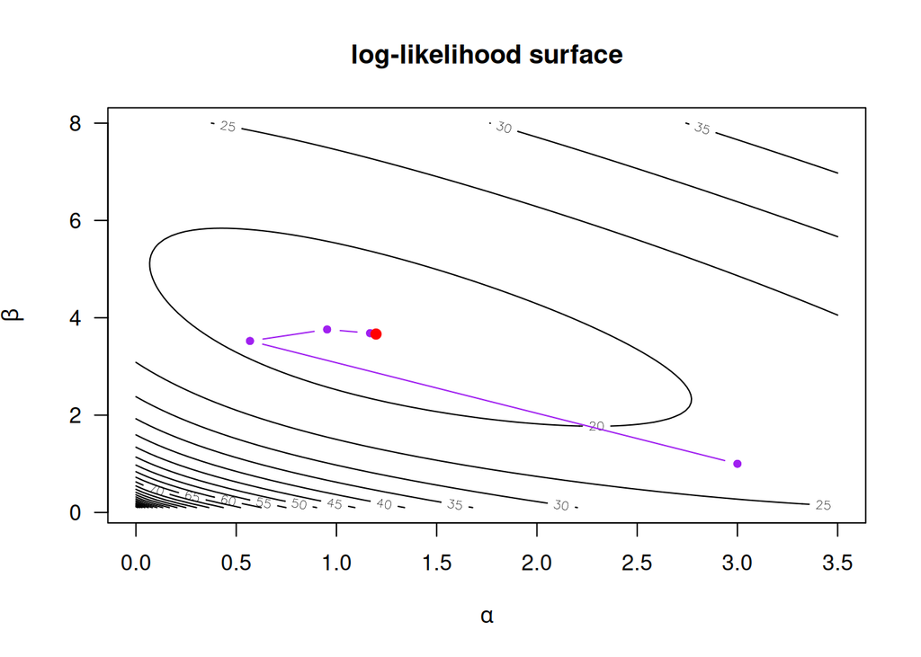

```r
f <- expression(-(alpha + beta * x) + y * log(alpha + beta * x))

da <- D(f, "alpha")
db <- D(f, "beta")
(dab <- D(da, "beta"))
(daa <- D(da, "alpha"))
(dbb <- D(db, "beta"))

init <- c(3, 1)
tol <- 0.01
l.current <- init
alpha <- l.current[1]
beta <- l.current[2]

contour(p1.v, p2.v, Z, add = FALSE, nlevels = 20,
        xlab = expression(alpha), ylab = expression(beta),
        main = "log-likelihood surface", las = 1)
points(alpha, beta, col = "purple", pch = 20)

g1 <- c(sum(eval(da)), sum(eval(db)))
H <- matrix(c(sum(eval(daa)), sum(eval(dab)),
              sum(eval(dab)), sum(eval(dbb))), nrow = 2)

l.new <- l.current - g1 %*% solve(H)
alpha <- l.new[1]
beta <- l.new[2]

lines(c(alpha, l.current[1]), c(beta, l.current[2]),
      col = "purple", pch = 20, type = "b")

for (i in 1:9) {
  l.current <- l.new

  g1 <- c(sum(eval(da)), sum(eval(db)))
  H <- matrix(c(sum(eval(daa)), sum(eval(dab)),
                sum(eval(dab)), sum(eval(dbb))), nrow = 2)

  l.new <- l.current - g1 %*% solve(H)
  alpha <- l.new[1]
  beta <- l.new[2]
  print(c(l.new))

  lines(c(alpha, l.current[1]), c(beta, l.current[2]),
        col = "purple", pch = 20, type = "b")
}

out <- optim(par = init, fn = llik.full)
points(out$par[1], out$par[2], pch = 19, col = "red")
```

# Question 5: Constrained (linear) optimization

Maximize $2x + 2y + 3z$ subject to

$$\begin{align*}
-2x + y + z & \le 1 \\
4x - y + 3z & \le 3 \\
x \ge 0, y \ge 0, z & \ge 0\\
\end{align*}$$

`constrOptim(theta, f, grad, ui, ci)`: Look at its help function and the example at the bottom of the help page.

For `constrOptim` the constraints need to be rephrased such that

$ui \cdot \theta - ci >= 0$, where $\theta$ is the parameter vector.